# Post-Disaster Demographic Changes

Matt Khinda, Jeb Polstein, Slide Kelly

10/25/2021

### Research Question

How well do demographic factors predict post-hurricane Sandy displacement? Which factors are most strongly correlated with displacement?

### Prior Research

Faber (2015) finds that flood risk in New York City during Hurricane Sandy varied by race and poverty. Black people were more likely than those of other races to live in areas that flooded, Latinx people were less likely to live in areas that flooded, and poverty rates were higher in areas that flooded than those that did not. Fussell and Harris (2014), studying displacement in New Orleans after Hurricane Katrina, find that renters were more likely to be displaced than homeowners.

### Data Sources

Our dataset will include the following American Community Survey 5-year estimate variables for years ending in 2011-2016:

Total Population in 2011 (Continuous — ACS) Total Population in 2013 (Continuous — ACS) Percent change in population (Continuous — calculated (2013 tot_pop - 2011 tot_pop)/(2011 tot_pop)* 100) Percent Race in 2011 (Continuous — ACS) Percent Hispanic in 2011 (Continuous - ACS) Median Income in 2011 (Continuous — ACS) Median Property Value (Continuous — ACS) Percent Renter in 2011 (Continuous — ACS) County (Categorical - ACS) Majority Vote Democrat/Republican 2008 Election (Categorical - MIT Election Lab) Location in flood plain (Categorical - FEMA flood maps)

The sample population is people in all census tracts within the following counties, which were highly affected by Sandy:

Ocean (NJ), Monmouth (NJ), Middlesex (NJ), Union (NJ), Essex (NJ), Hudson (NJ), Bergen (NJ), Westchester (NY), Rockland (NY), Bronx (NY), New York (NY), Kings (NY), Queens (NY), Richmond (NY), Nassau (NY), Suffolk (NY), Fairfield (CT), New Haven (CT)

### Load Data

```r
library(tidyverse)
library(tidycensus)
```

```r
library(readxl)
library(knitr)
library(ggplot2)
library(sf)
library(ggspatial)
library(here)
library(stringr)
library(gridExtra)
library(jtools)
library(interactions)
#load NY 2011 data
ny_acs_2011 <- get_acs(geography = "tract",
                       county = c("Queens",
                                  "Westchester",
                                  "Rockland",
                                  "Richmond",
                                  "Bronx",
                                  "New York",
                                  "Kings",
                                  "Nassau",
                                  "Suffolk"),
                        state = "NY",
                        year = 2011, survey = "acs5",
                        variables = c(
                             total_pop_2011 = "B01003_001",

                             black_pop_2011 = "B02001_003",
                             white_pop_2011 = "B02001_002",
                             native_pop_2011 = "B02001_004",
                             asian_pop_2011 = "B02001_005",
                             hawaiian_pop_2011 = "B02001_006",
                             hispanic_pop_2011 = "B03001_003",

                             med_income_2011 = "B19013_001",
                             med_propvalue_2011 = "B25077_001",
                             tot_renter_2011 = "B25003_003"),
                        output = "wide", geometry = TRUE)

#load NY 2013 data
ny_acs_2013 <- get_acs(geography = "tract",
                       county = c("Queens",
                                  "Westchester",
                                  "Rockland",
                                  "Richmond",
                                  "Bronx",
                                  "New York",
                                  "Kings",
                                  "Nassau",
                                  "Suffolk"),
                        state = "NY",
                        year = 2013, survey = "acs5",
                        variables = c(
                             total_pop_2013 = "B01003_001"),
                        output = "wide", geometry = TRUE)

ny_acs_2013 <- ny_acs_2013 %>%
  st_set_geometry(NULL)

full_ny <- merge(x = ny_acs_2011, y = ny_acs_2013)


#load NJ 2011 data
nj_acs_2011 <- get_acs(geography = "tract",
                       county = c("Ocean",
                                  "Union",
                                  "Essex",
                                  "Bergen",
                                  "Hudson",
                                  "Middlesex",
                                  "Monmouth"),
                        state = "NJ",
                        year = 2011, survey = "acs5",
                         variables = c(
                             total_pop_2011 = "B01003_001",

                             black_pop_2011 = "B02001_003",
                             white_pop_2011 = "B02001_002",
                             native_pop_2011 = "B02001_004",
                             asian_pop_2011 = "B02001_005",
                             hawaiian_pop_2011 = "B02001_006",
                             hispanic_pop_2011 = "B03001_003",

                             med_income_2011 = "B19013_001",
                             med_propvalue_2011 = "B25077_001",
                             tot_renter_2011 = "B25003_003"),
                        output = "wide", geometry = TRUE)

#load NJ 2013 data
nj_acs_2013 <- get_acs(geography = "tract",
                       county = c("Ocean",
                                  "Union",
                                  "Essex",
                                  "Bergen",
                                  "Hudson",
                                  "Middlesex",
                                  "Monmouth"),
                        state = "NJ",
                        year = 2013, survey = "acs5",
                         variables = c(
                             total_pop_2013 = "B01003_001"),
                        output = "wide", geometry = TRUE)

nj_acs_2013 <- nj_acs_2013 %>%
  st_set_geometry(NULL)

full_nj <- merge(x = nj_acs_2011, y = nj_acs_2013)


#load CT 2011 data
ct_acs_2011 <- get_acs(geography = "tract",
                       county = c("New Haven",
                                  "Fairfield"),
                        state = "CT",
                        year = 2011, survey = "acs5",
                        variables = c(
                             total_pop_2011 = "B01003_001",

                             black_pop_2011 = "B02001_003",
                             white_pop_2011 = "B02001_002",
                             native_pop_2011 = "B02001_004",
                             asian_pop_2011 = "B02001_005",
                             hawaiian_pop_2011 = "B02001_006",
                             hispanic_pop_2011 = "B03001_003",

                             med_income_2011 = "B19013_001",
                             med_propvalue_2011 = "B25077_001",
                             tot_renter_2011 = "B25003_003"),
                        output = "wide", geometry = TRUE)


#load CT 2013 data
ct_acs_2013 <- get_acs(geography = "tract",
                       county = c("New Haven",
                                  "Fairfield"),
                        state = "CT",
                        year = 2013, survey = "acs5",
                        variables = c(
                             total_pop_2013 = "B01003_001"),
                        output = "wide", geometry = TRUE)

ct_acs_2013 <- ct_acs_2013 %>%
  st_set_geometry(NULL)

full_ct <- merge(x = ct_acs_2011, y = ct_acs_2013)


#combine all data
full_acs <- rbind(full_ny,full_nj,full_ct)

#filter out tracts with 0 population
full_acs <- full_acs %>%
  filter(total_pop_2011E != 0)

#create new variables
full_acs <- full_acs %>%
  mutate(county = sapply(strsplit(NAME,", "), `[`, 2)) %>%
  mutate(pct_pop_changeE = round(((total_pop_2013E - total_pop_2011E)/total_pop_2011E)*100, 2)) %>%
  mutate(pct_black_pop_2011E = round((black_pop_2011E/total_pop_2011E)*100, 2)) %>%
  mutate(pct_white_pop_2011E = round((white_pop_2011E/total_pop_2011E)*100, 2)) %>%
  mutate(pct_native_pop_2011E = round((native_pop_2011E/total_pop_2011E)*100, 2)) %>%
  mutate(pct_asian_pop_2011E = round((asian_pop_2011E/total_pop_2011E)*100, 2)) %>%
  mutate(pct_hawaiian_pop_2011E = round((hawaiian_pop_2011E/total_pop_2011E)*100, 2)) %>%
  mutate(pct_hispanic_pop_2011E = round((hispanic_pop_2011E/total_pop_2011E)*100, 2)) %>%
  mutate(pct_renter_2011E = round((tot_renter_2011E/total_pop_2011E)*100, 2)) %>%
  mutate(tract_area = st_area(geometry)) %>%
  mutate(pop_density_2011E = round((total_pop_2011E/tract_area)*100, 2))

#read in election data
ourstates <- c("NY", "NJ", "CT")
ourcounties <- c( "Queens",
                  "Westchester",
                  "Rockland",
                  "Richmond",
                  "Bronx",
                  "New York",
                  "Kings",
                  "Nassau",
                  "Suffolk",
                  "Ocean",
                  "Union",
                  "Essex",
                  "Bergen",
                  "Hudson",
                  "Middlesex",
                  "Monmouth",
                  "New Haven",
                  "Fairfield")

election <- read_csv(here("Data", "countypres_2000-2020.csv")) %>%
  filter(state_po %in% ourstates) %>%
  mutate(county_name = str_to_title(county_name)) %>%
  filter(county_name %in% ourcounties) %>%
  filter(year == 2008) %>%
  filter(party == "REPUBLICAN") %>%
  rename(GEOID = county_name) %>%
  group_by(GEOID) %>%
  summarize(candidatevotes = sum(candidatevotes),
            totalvotes = first(totalvotes)) %>%
  mutate(pct_GOP = candidatevotes / totalvotes) %>%
  mutate(majority_vote = ifelse(pct_GOP > 0.5, "Republican", "Democrat")) %>%
  select(GEOID, pct_GOP, majority_vote) %>%
  mutate(addcounty = "County") %>%
  mutate(county_name = paste(GEOID, addcounty, sep = " ")) %>%
  select(county_name, majority_vote)

#adding election data to full acs
full_acs <- merge(full_acs, election, by.x = "county", by.y = "county_name")

#adding in flood data
floodplain <- read_sf(here("Data", "floodedtracts.shp"))

floodplain <- floodplain %>%
  mutate(flooded = "Y") %>%
  st_set_geometry(NULL) %>%
  select(GEOID, flooded)

#merge floodplain with full
full_acs <- merge(full_acs, floodplain, by = "GEOID", all.x = "TRUE")

full_acs <- full_acs %>%
  mutate(flooded = replace_na(flooded, "N"))
```

```r
kable(head(full_acs))
```

| GEOID | county | NAME | total_pop_2011E | total_pop_2011M | black_pop_2011E | black_pop_2011M | white_pop_2011E | white_pop_2011M | native_pop_2011E | native_pop_2011M | asian_pop_2011E | asian_pop_2011M | hawaiian_pop_2011E | hawaiian_pop_2011M | hispanic_pop_2011E | hispanic_pop_2011M | med_income_2011E | med_income_2011M | med_propvalue_2011E | med_propvalue_2011M | tot_renter_2011E | tot_renter_2011M | total_pop_2013E | total_pop_2013M | pct_pop_changeE | pct_black_pop_2011E | pct_white_pop_2011E | pct_native_pop_2011E | pct_asian_pop_2011E | … |
| --- | --- | --- | --- | --- | --- | --- | --- | --- | --- | --- | --- | --- | --- | --- | --- | --- | --- | --- | --- | --- | --- | --- | --- | --- | --- | --- | --- | --- | --- | --- |
| 09001010101 | Fairfield County | Census Tract 101.01, Fairfield County, Connecticut | 4107 | 259 | 8 | 13 | 3987 | 267 | 0 | 92 | 94 | 100 | 0 | 92 | 193 | 129 | 154421 | 38574 | 1000001 | NA | 236 | 115 | 4221 | 397 | 2.78 | 0.19 | 97.08 | 0 | 2.29 | … |
| 09001010102 | Fairfield County | Census Tract 101.02, Fairfield County, Connecticut | 4577 | 400 | 78 | 73 | 4007 | 344 | 0 | 92 | 436 | 298 | 0 | 92 | 239 | 148 | 241944 | 74128 | 1000001 | NA | 174 | 89 | 4216 | 399 | -7.89 | 1.70 | 87.55 | 0 | 9.53 | … |
| 09001010201 | Fairfield County | Census Tract 102.01, Fairfield County, Connecticut | 3487 | 419 | 127 | 152 | 3075 | 401 | 0 | 92 | 126 | 79 | 0 | 92 | 154 | 114 | 250001 | NA | 1000001 | NA | 66 | 41 | 3471 | 349 | -0.46 | 3.64 | 88.18 | 0 | 3.61 | … |
| 09001010202 | Fairfield County | Census Tract 102.02, Fairfield County, Connecticut | 5080 | 335 | 85 | 76 | 4369 | 341 | 0 | 92 | 542 | 199 | 0 | 92 | 227 | 146 | 175625 | 26091 | 1000001 | NA | 236 | 77 | 5245 | 378 | 3.25 | 1.67 | 86.00 | 0 | 10.67 | … |
| 09001010300 | Fairfield County | Census Tract 103, Fairfield County, Connecticut | 4066 | 285 | 55 | 84 | 3522 | 322 | 0 | 92 | 372 | 244 | 0 | 92 | 302 | 208 | 152321 | 31544 | 1000001 | NA | 341 | 104 | 3974 | 261 | -2.26 | 1.35 | 86.62 | 0 | 9.15 | … |
| 09001010400 | Fairfield County | Census Tract 104, Fairfield County, Connecticut | 5130 | 430 | 35 | 42 | 4743 | 402 | 0 | 92 | 271 | 296 | 0 | 92 | 362 | 175 | 83036 | 13226 | 723300 | 53326 | 517 | 136 | 5288 | 478 | 3.08 | 0.68 | 92.46 | 0 | 5.28 | … |

The dataset includes 4515 census tracts.

### Descriptive Statistics - Continuous

```r
pct_pop_change_t_test <- t.test(full_acs$pct_pop_changeE)
pct_black_pop_2011_t_test <- t.test(full_acs$pct_black_pop_2011E)
pct_white_pop_2011_t_test <- t.test(full_acs$pct_white_pop_2011E)
pct_asian_pop_2011_t_test <- t.test(full_acs$pct_asian_pop_2011E)
pct_hispanic_pop_2011_t_test <- t.test(full_acs$pct_hispanic_pop_2011E)
pct_renter_2011_t_test <- t.test(full_acs$pct_renter_2011E)
med_income_2011_t_test <- t.test(full_acs$med_income_2011E)
med_propvalue_2011_t_test <- t.test(full_acs$med_propvalue_2011E)
#pop_density_2011_t_test <- t.test(full_acs$pop_density_2011E)
```

```r
pct_pop_change_quartiles <- quantile(full_acs$pct_pop_changeE, na.rm = TRUE)
pct_black_pop_2011_quartiles <- quantile(full_acs$pct_black_pop_2011E, na.rm = TRUE)
pct_white_pop_2011_quartiles <- quantile(full_acs$pct_white_pop_2011E, na.rm = TRUE)
pct_asian_pop_2011_quartiles <- quantile(full_acs$pct_asian_pop_2011E, na.rm = TRUE)
pct_hispanic_pop_2011_quartiles <- quantile(full_acs$pct_hispanic_pop_2011E, na.rm = TRUE)
pct_renter_2011_quartiles <- quantile(full_acs$pct_renter_2011E, na.rm = TRUE)
med_income_2011_quartiles <- quantile(full_acs$med_income_2011E, na.rm = TRUE)
med_propvalue_2011_quartiles <- quantile(full_acs$med_propvalue_2011E, na.rm = TRUE)
```

```r
pct_pop_change_st_dev <- sd(full_acs$pct_pop_changeE, na.rm = TRUE)
pct_black_pop_2011_st_dev <- sd(full_acs$pct_black_pop_2011E, na.rm = TRUE)
pct_white_pop_2011_st_dev <- sd(full_acs$pct_white_pop_2011E, na.rm = TRUE)
pct_asian_pop_2011_st_dev <- sd(full_acs$pct_asian_pop_2011E, na.rm = TRUE)
pct_hispanic_pop_2011_st_dev <- sd(full_acs$pct_hispanic_pop_2011E, na.rm = TRUE)
pct_renter_2011_st_dev <- sd(full_acs$pct_renter_2011, na.rm = TRUE)
med_income_2011_st_dev <- sd(full_acs$med_income_2011E, na.rm = TRUE)
med_propvalue_2011_st_dev <- sd(full_acs$med_propvalue_2011E, na.rm = TRUE)
```

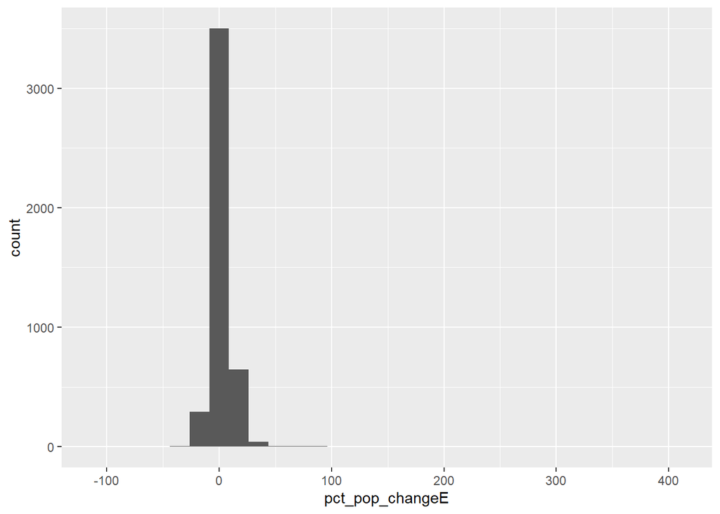

```r
pct_pop_change_hist <- ggplot(full_acs) +
  geom_histogram(aes(x = pct_pop_changeE),
                 bins = 30)

pct_black_pop_2011_hist <- ggplot(full_acs) +
  geom_histogram(aes(x = pct_black_pop_2011E),
                 bins = 30)

pct_white_pop_2011_hist <- ggplot(full_acs) +
  geom_histogram(aes(x = pct_white_pop_2011E),
                 bins = 30)

pct_asian_pop_2011_hist <- ggplot(full_acs) +
  geom_histogram(aes(x = pct_asian_pop_2011E),
                 bins = 30)

pct_hispanic_pop_2011_hist <- ggplot(full_acs) +
  geom_histogram(aes(x = pct_hispanic_pop_2011E),
                 bins = 30)

pct_renter_2011_hist <- ggplot(full_acs) +
  geom_histogram(aes(x = pct_renter_2011E),
                 bins = 30)

med_income_2011_hist <- ggplot(full_acs) +
  geom_histogram(aes(x = med_income_2011E),
                 bins = 30)

med_propvalue_2011_hist <- ggplot(full_acs) +
  geom_histogram(aes(x = med_propvalue_2011E),
                 bins = 30)

pct_pop_change_hist
```

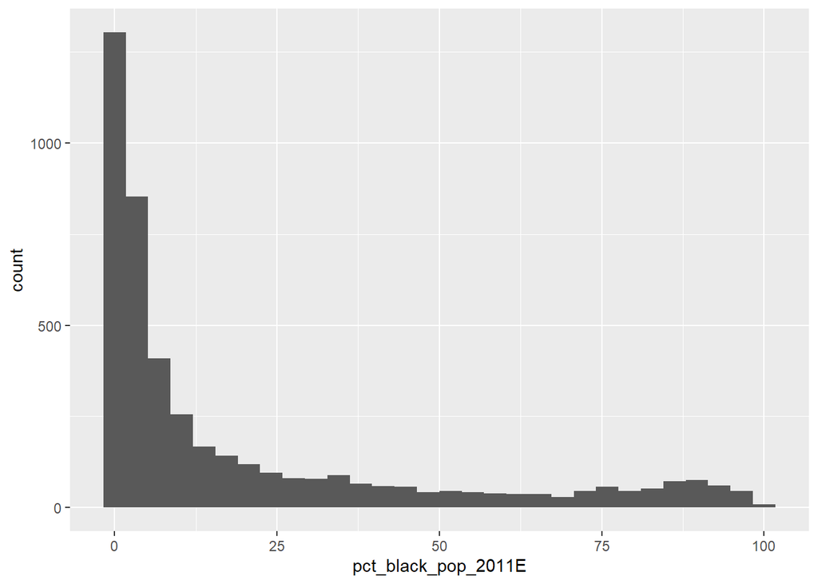

```r
pct_black_pop_2011_hist
```

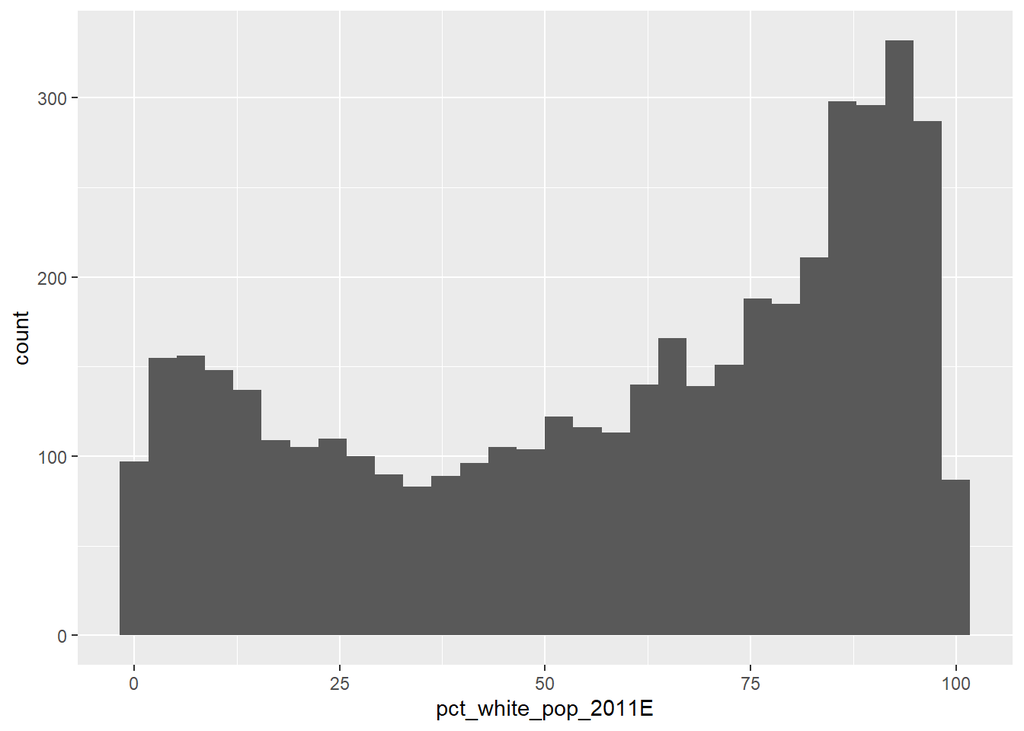

```r
pct_white_pop_2011_hist
```

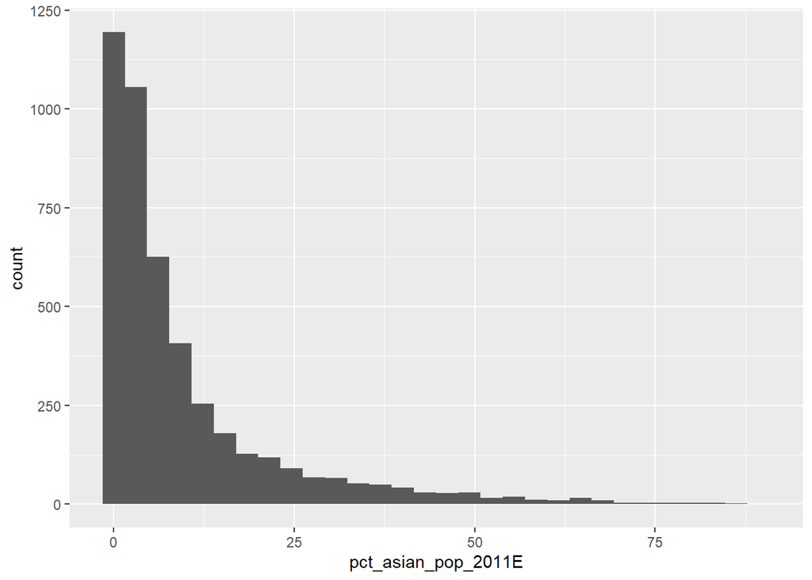

```r
pct_asian_pop_2011_hist
```

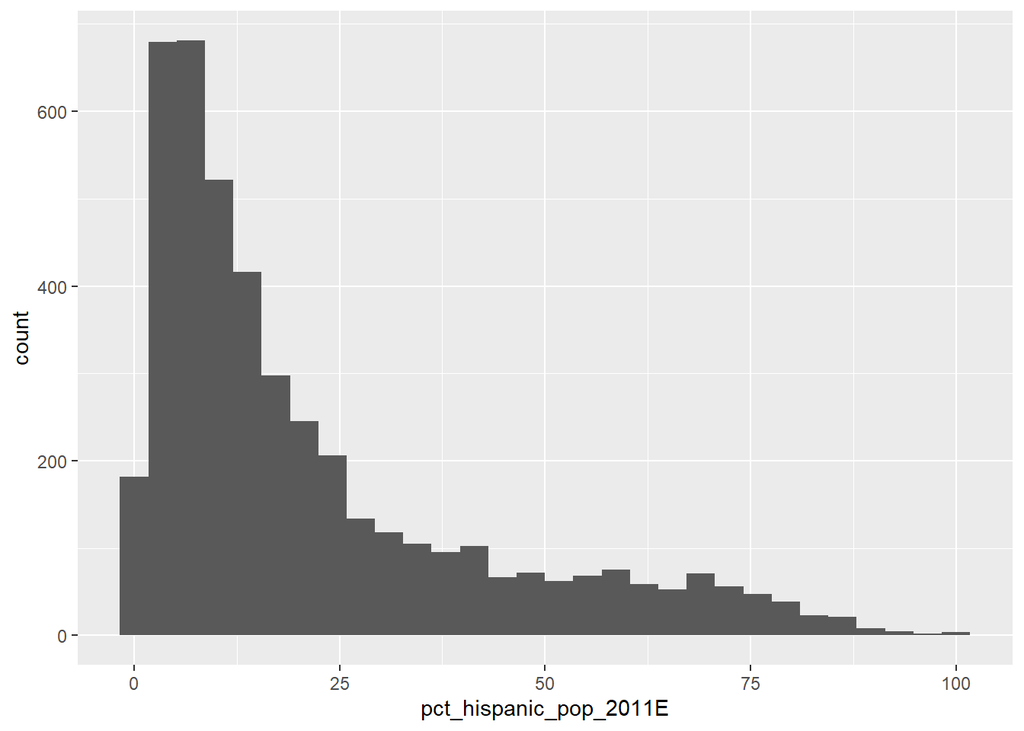

```r
pct_hispanic_pop_2011_hist
```

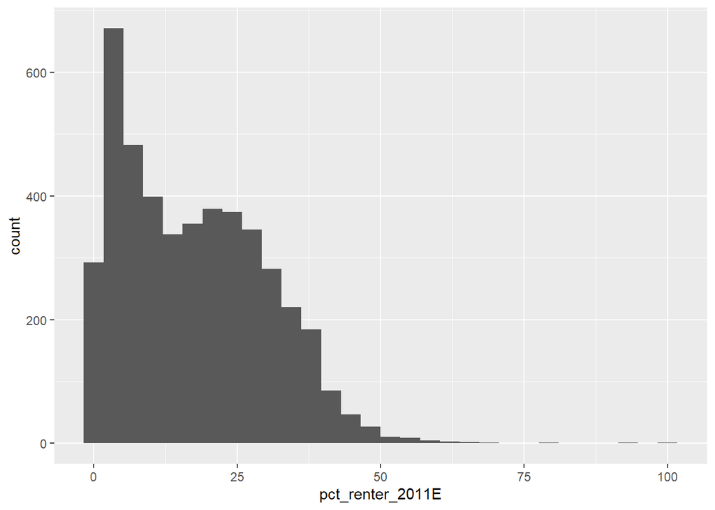

```r
pct_renter_2011_hist
```

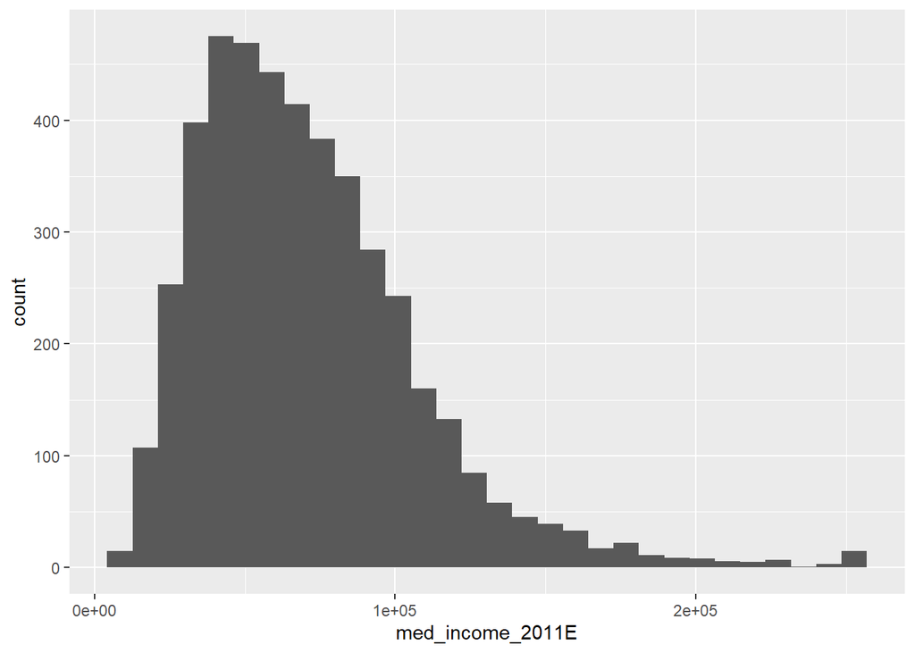

```r
med_income_2011_hist
```

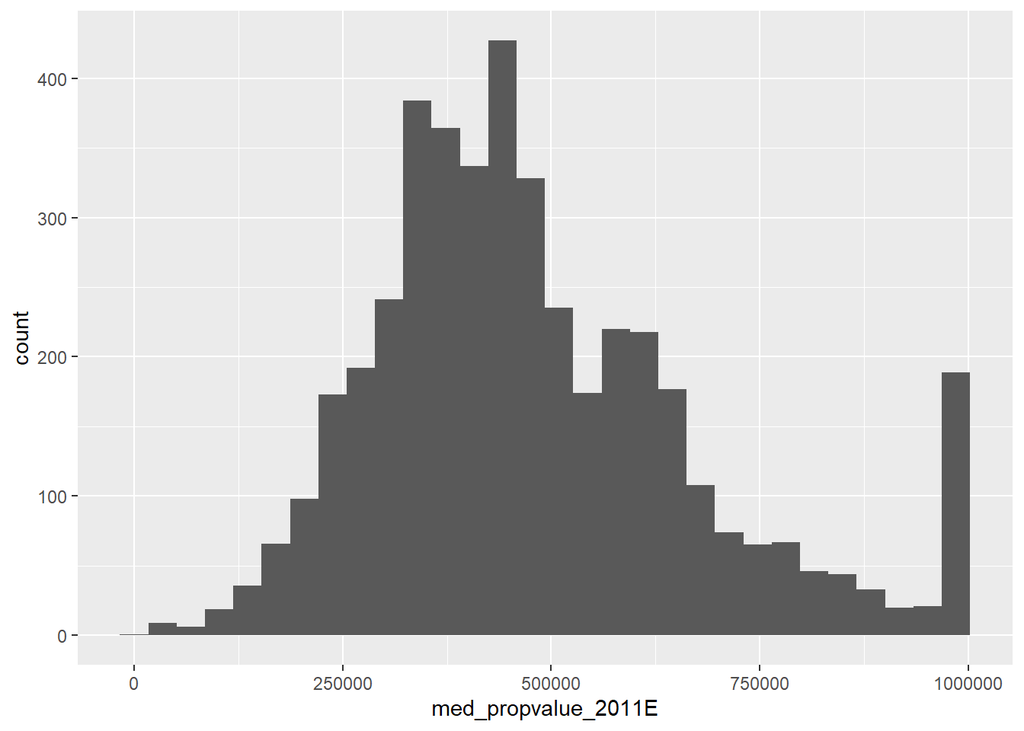

```r
med_propvalue_2011_hist
```

```r
cont_summary <- tibble(
  Variable = c("Percent Population Change",
               "Percent Black",
               "Percent White",
               "Percent Asian",
               "Percent Hispanic",
               "Percent Renter",
               "Median Income",
               "Median Property Value"),

   `Sample mean` = c(pct_pop_change_t_test$estimate,
                    pct_black_pop_2011_t_test$estimate,
                    pct_white_pop_2011_t_test$estimate,
                    pct_asian_pop_2011_t_test$estimate,
                    pct_hispanic_pop_2011_t_test$estimate,
                    pct_renter_2011_t_test$estimate,
                    med_income_2011_t_test$estimate,
                    med_propvalue_2011_t_test$estimate),

  `Population mean (95% confidence) - low` =
    c(pct_pop_change_t_test$conf.int[1],
      pct_black_pop_2011_t_test$conf.int[1],
      pct_white_pop_2011_t_test$conf.int[1],
      pct_asian_pop_2011_t_test$conf.int[1],
      pct_hispanic_pop_2011_t_test$conf.int[1],
      pct_renter_2011_t_test$conf.int[1],
      med_income_2011_t_test$conf.int[1],
      med_propvalue_2011_t_test$conf.int[1]),

  `Population mean (95% confidence) - high` =
    c(pct_pop_change_t_test$conf.int[2],
      pct_black_pop_2011_t_test$conf.int[2],
      pct_white_pop_2011_t_test$conf.int[2],
      pct_asian_pop_2011_t_test$conf.int[2],
      pct_hispanic_pop_2011_t_test$conf.int[2],
      pct_renter_2011_t_test$conf.int[2],
      med_income_2011_t_test$conf.int[2],
      med_propvalue_2011_t_test$conf.int[2]),

  Median = c(pct_pop_change_quartiles[3],
             pct_black_pop_2011_quartiles[3],
             pct_white_pop_2011_quartiles[3],
             pct_asian_pop_2011_quartiles[3],
             pct_hispanic_pop_2011_quartiles[3],
             pct_renter_2011_quartiles[3],
             med_income_2011_quartiles[3],
             med_propvalue_2011_quartiles[3]),

  `Interquartile range` = c(pct_pop_change_quartiles[4] - pct_pop_change_quartiles[2],
                            pct_black_pop_2011_quartiles[4] - pct_black_pop_2011_quartiles[2],
                            pct_white_pop_2011_quartiles[4] - pct_white_pop_2011_quartiles[2],
                            pct_asian_pop_2011_quartiles[4] - pct_asian_pop_2011_quartiles[2],
                            pct_hispanic_pop_2011_quartiles[4] -  pct_hispanic_pop_2011_quartiles[2],
                            pct_renter_2011_quartiles[4] - pct_renter_2011_quartiles[2],
                            med_income_2011_quartiles[4] - med_income_2011_quartiles[2],
                            med_propvalue_2011_quartiles[4] - med_propvalue_2011_quartiles[2]),

  `Standard deviation` = c(pct_pop_change_st_dev,
                           pct_black_pop_2011_st_dev,
                           pct_white_pop_2011_st_dev,
                           pct_asian_pop_2011_st_dev,
                           pct_hispanic_pop_2011_st_dev,
                           pct_renter_2011_st_dev,
                           med_income_2011_st_dev,
                           med_propvalue_2011_st_dev
                          ))

kable(cont_summary, digits = 0)
```

| Variable | Sample mean | Population mean (95% confidence) - low | Population mean (95% confidence) - high | Median | Interquartile range | Standard deviation |
| --- | --- | --- | --- | --- | --- | --- |
| Percent Population Change | 2 | 2 | 2 | 1 | 9 | 11 |
| Percent Black | 20 | 19 | 21 | 6 | 26 | 27 |
| Percent White | 58 | 57 | 59 | 66 | 57 | 31 |
| Percent Asian | 10 | 9 | 10 | 5 | 10 | 13 |
| Percent Hispanic | 22 | 21 | 22 | 14 | 23 | 21 |
| Percent Renter | 18 | 17 | 18 | 16 | 21 | 13 |
| Median Income | 71017 | 69936 | 72097 | 64531 | 46468 | 36936 |
| Median Property Value | 480590 | 474739 | 486442 | 445550 | 243450 | 197338 |

### Descriptive Statistics - Cagetgorical

```r
democrat_t_test <- t.test(full_acs$majority_vote == unique(full_acs$majority_vote)[1])
republican_t_test <- t.test(full_acs$majority_vote == unique(full_acs$majority_vote)[2])

cat_summary_party <- tibble(`Majority Party in 2008` =
                              c("Democrat",
                                "Republican"),
                            `Sample proportion` =
                              c(democrat_t_test$estimate * 100,
                                republican_t_test$estimate *100),
                            `95-percent confidence - low` =
                              c(democrat_t_test$conf.int[1] * 100,
                                republican_t_test$conf.int[1] * 100),
                            `95-percent confidence - high` =
                              c(democrat_t_test$conf.int[2] * 100,
                                republican_t_test$conf.int[2] * 100))

kable(cat_summary_party, digits = 1)
```

| Majority Party in 2008 | Sample proportion | 95-percent confidence - low | 95-percent confidence - high |
| --- | --- | --- | --- |
| Democrat | 87.8 | 86.9 | 88.8 |
| Republican | 12.2 | 11.2 | 13.1 |

```r
flooded_t_test <- t.test(full_acs$flooded == unique(full_acs$flooded)[1])

cat_summary_flooded <- tibble('Flooded Tracts' =
                              c("Yes"
                                ),
                            `Sample proportion` =
                              c(flooded_t_test$estimate * 100),
                            `95-percent confidence - low` =
                              c(flooded_t_test$conf.int[1] * 100),
                            `95-percent confidence - high` =
                              c(flooded_t_test$conf.int[2] * 100))


kable(cat_summary_flooded, digits = 1)
```

| Flooded Tracts | Sample proportion | 95-percent confidence - low | 95-percent confidence - high |
| --- | --- | --- | --- |
| Yes | 45.7 | 44.3 | 47.2 |

### Correlation Tests

```r
cor.test(~ pct_pop_changeE + pct_black_pop_2011E, data = full_acs)
```

```
##
##  Pearson's product-moment correlation
##
## data:  pct_pop_changeE and pct_black_pop_2011E
## t = -0.067642, df = 4513, p-value = 0.9461
## alternative hypothesis: true correlation is not equal to 0
## 95 percent confidence interval:
##  -0.03017626  0.02816420
## sample estimates:
##          cor
## -0.001006888
```

```r
cor.test(~ pct_pop_changeE + pct_white_pop_2011E, data = full_acs)
```

```
##
##  Pearson's product-moment correlation
##
## data:  pct_pop_changeE and pct_white_pop_2011E
## t = -3.0155, df = 4513, p-value = 0.00258
## alternative hypothesis: true correlation is not equal to 0
## 95 percent confidence interval:
##  -0.07391596 -0.01569265
## sample estimates:
##         cor
## -0.04484239
```

```r
cor.test(~ pct_pop_changeE + pct_asian_pop_2011E, data = full_acs)
```

```
##
##  Pearson's product-moment correlation
##
## data:  pct_pop_changeE and pct_asian_pop_2011E
## t = 5.4876, df = 4513, p-value = 4.298e-08
## alternative hypothesis: true correlation is not equal to 0
## 95 percent confidence interval:
##  0.05236876 0.11032291
## sample estimates:
##        cor
## 0.08141466
```

```r
cor.test(~ pct_pop_changeE + pct_hispanic_pop_2011E, data = full_acs)
```

```
##
##  Pearson's product-moment correlation
##
## data:  pct_pop_changeE and pct_hispanic_pop_2011E
## t = 1.5433, df = 4513, p-value = 0.1228
## alternative hypothesis: true correlation is not equal to 0
## 95 percent confidence interval:
##  -0.006207957  0.052101819
## sample estimates:
##        cor
## 0.02296646
```

```r
cor.test(~ pct_pop_changeE + pct_renter_2011E, data = full_acs)
```

```
##
##  Pearson's product-moment correlation
##
## data:  pct_pop_changeE and pct_renter_2011E
## t = 7.3971, df = 4513, p-value = 1.65e-13
## alternative hypothesis: true correlation is not equal to 0
## 95 percent confidence interval:
##  0.08053647 0.13817870
## sample estimates:
##       cor
## 0.1094496
```

```r
cor.test(~ pct_pop_changeE + med_income_2011E, data = full_acs)
```

```
##
##  Pearson's product-moment correlation
##
## data:  pct_pop_changeE and med_income_2011E
## t = -3.0595, df = 4489, p-value = 0.00223
## alternative hypothesis: true correlation is not equal to 0
## 95 percent confidence interval:
##  -0.07476479 -0.01639019
## sample estimates:
##         cor
## -0.04561643
```

```r
cor.test(~ pct_pop_changeE + med_propvalue_2011E, data = full_acs)
```

```
##
##  Pearson's product-moment correlation
##
## data:  pct_pop_changeE and med_propvalue_2011E
## t = 0.44573, df = 4370, p-value = 0.6558
## alternative hypothesis: true correlation is not equal to 0
## 95 percent confidence interval:
##  -0.02290563  0.03637872
## sample estimates:
##         cor
## 0.006742468
```

#### Correlation Interpretation

The correlation tests tell us that there is a significant relationship between percent population change and: percent white, percent Asian, percent renter, and median income. Increases in white population and median income are associated with a decrease in percent population change. Increases in Asian population and percent renter are associated with an increase in percent population change. There is not a significant relationship between percent population change and: percent Black, percent Hispanic, and median property value.

### Categorical T-Test

```r
t.test(pct_pop_changeE ~ majority_vote, full_acs)
```

```
##
##  Welch Two Sample t-test
##
## data:  pct_pop_changeE by majority_vote
## t = 3.7679, df = 1022.4, p-value = 0.000174
## alternative hypothesis: true difference in means between group Democrat and group Republican is not equal to 0
## 95 percent confidence interval:
##  0.6417146 2.0365199
## sample estimates:
##   mean in group Democrat mean in group Republican
##                2.0747718                0.7356545
```

There is a significant relationship between percent population change and majority vote. Democratic counties overall have higher percent population change than Republican counties.

```r
t.test(pct_pop_changeE ~ flooded, full_acs)
```

```
##
##  Welch Two Sample t-test
##
## data:  pct_pop_changeE by flooded
## t = -0.42011, df = 3982.7, p-value = 0.6744
## alternative hypothesis: true difference in means between group N and group Y is not equal to 0
## 95 percent confidence interval:
##  -0.8151925  0.5274823
## sample estimates:
## mean in group N mean in group Y
##        1.845883        1.989738
```

There is no significant relationship between percent population change and whether or not a tract is in the flood zone.

### Visualizations

To better understand the correlations, we created a set of scatter plots.

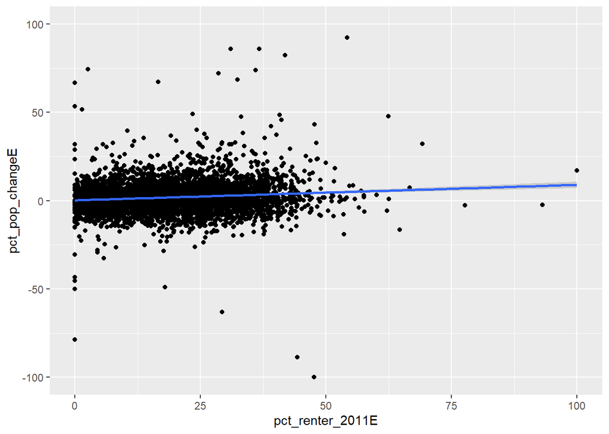

```r
renter_pop_plot <- ggplot(full_acs, aes(pct_renter_2011E, pct_pop_changeE))+
  geom_point() + ylim(-100, 100)


renter_pop_plot + stat_smooth(
              method = "lm",
              formula = y ~ x,
              geom = "smooth")
```

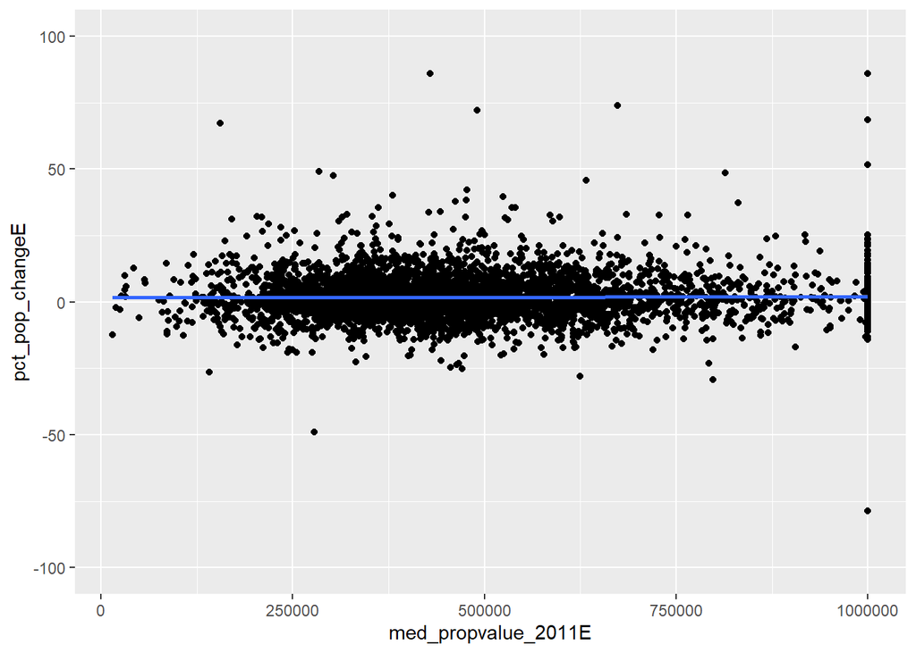

```r
propvalue_plot <- ggplot(full_acs, aes(med_propvalue_2011E, pct_pop_changeE))+
  geom_point() + ylim(-100, 100)


propvalue_plot + stat_smooth(
              method = "lm",
              formula = y ~ x,
              geom = "smooth")
```

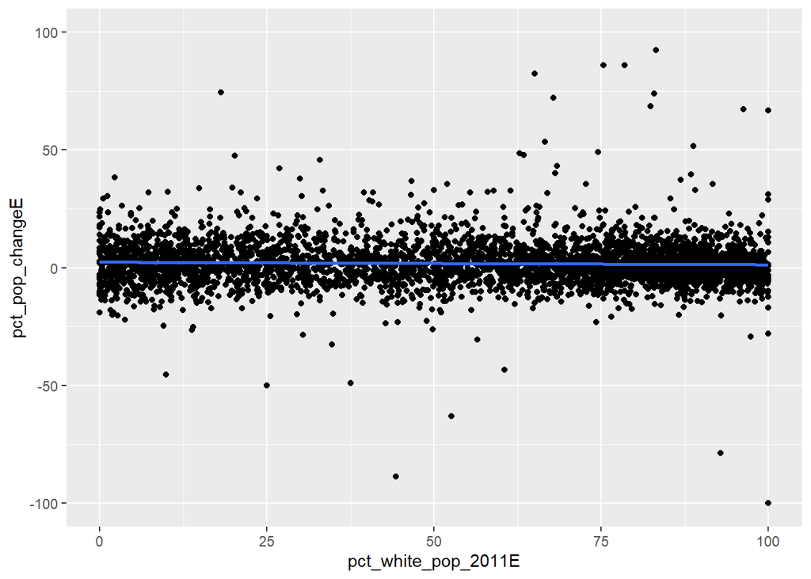

```r
white_pop_plot <- ggplot(full_acs, aes(pct_white_pop_2011E, pct_pop_changeE))+
  geom_point() + ylim(-100, 100)


white_pop_plot + stat_smooth(
              method = "lm",
              formula = y ~ x,
              geom = "smooth")
```

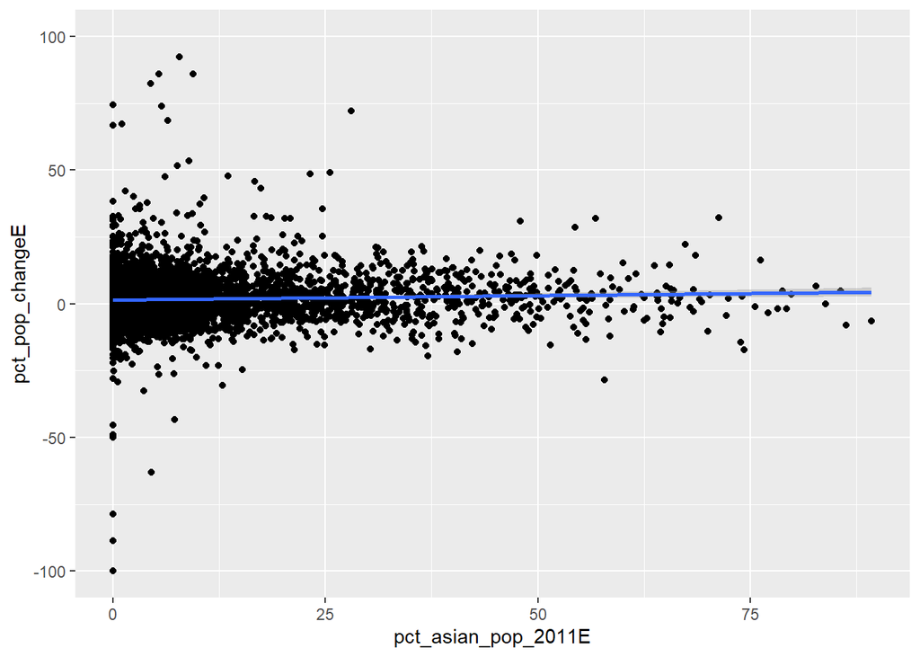

```r
asian_pop_plot <- ggplot(full_acs, aes(pct_asian_pop_2011E, pct_pop_changeE))+
  geom_point() + ylim(-100, 100)


asian_pop_plot + stat_smooth(
              method = "lm",
              formula = y ~ x,
              geom = "smooth")
```

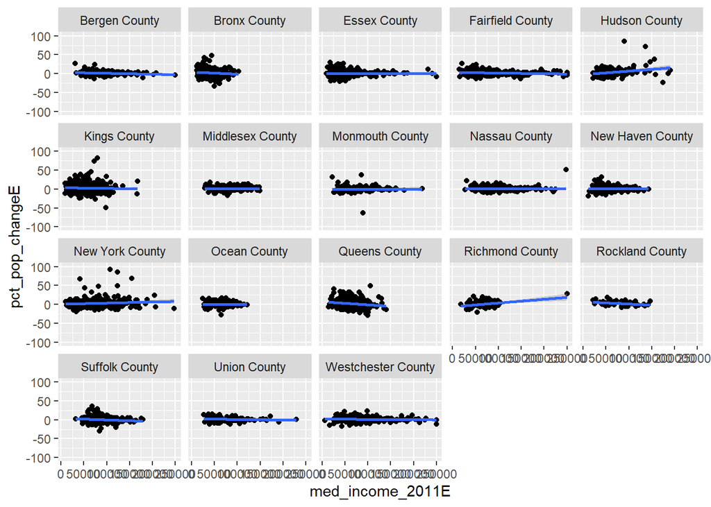

```r
income_pop_plot <- ggplot(full_acs, aes(med_income_2011E, pct_pop_changeE))+
  geom_point() + ylim(-100, 100)+
  facet_wrap(vars(county))


income_pop_plot + stat_smooth(
              method = "lm",
              formula = y ~ x,
              geom = "smooth")
```

#### Visualization Interpreation

From these visualizations, specifically the one that was facet wrapped by county, we can see that there are significant outliers in positive change in population in New York County and Kings County (Manhattan and Brooklyn in New York City). We wanted to acknowledge that these may have a disproportionate influence on the correlations between overall demographics and overall population change.

### Multivariate Regression

```r
full_model_com <- lm(pct_pop_changeE ~ pct_black_pop_2011E + pct_white_pop_2011E + pct_asian_pop_2011E + pct_hispanic_pop_2011E + pct_renter_2011E + med_income_2011E + med_propvalue_2011E + majority_vote + flooded, full_acs)

summary(full_model_com)
```

```
##
## Call:
## lm(formula = pct_pop_changeE ~ pct_black_pop_2011E + pct_white_pop_2011E +
##     pct_asian_pop_2011E + pct_hispanic_pop_2011E + pct_renter_2011E +
##     med_income_2011E + med_propvalue_2011E + majority_vote +
##     flooded, data = full_acs)
##
## Residuals:
##     Min      1Q  Median      3Q     Max
## -50.955  -4.576  -0.483   3.826  82.411
##
## Coefficients:
##                           Estimate Std. Error t value Pr(>|t|)
## (Intercept)              3.537e-01  1.881e+00   0.188   0.8509
## pct_black_pop_2011E     -9.835e-03  1.900e-02  -0.518   0.6047
## pct_white_pop_2011E     -6.970e-03  1.755e-02  -0.397   0.6914
## pct_asian_pop_2011E      2.051e-02  2.081e-02   0.985   0.3245
## pct_hispanic_pop_2011E   2.032e-03  1.216e-02   0.167   0.8673
## pct_renter_2011E         8.919e-02  1.398e-02   6.382 1.94e-10 ***
## med_income_2011E         1.360e-06  5.601e-06   0.243   0.8081
## med_propvalue_2011E      8.336e-10  8.192e-07   0.001   0.9992
## majority_voteRepublican -7.108e-01  4.133e-01  -1.720   0.0856 .
## floodedY                 6.403e-01  2.889e-01   2.216   0.0267 *
## ---
## Signif. codes:  0 '***' 0.001 '**' 0.01 '*' 0.05 '.' 0.1 ' ' 1
##
## Residual standard error: 8.265 on 4361 degrees of freedom
##   (144 observations deleted due to missingness)
## Multiple R-squared:  0.02058,    Adjusted R-squared:  0.01856
## F-statistic: 10.18 on 9 and 4361 DF,  p-value: 1.149e-15
```

#### Multivariate Regression Interpretation

When all variables are estimated together in multivariate regression, we found that all continuous variables estimated in bivariate regression demonstrated a weaker correlation with population change then when estimated alone. Percent renter remained significantly correlated with population change, with each additional percent change in renter explaining 0.089% increase in population change.

Both categorical variables show very minor but some significant correlation with population change. Whether a census tract was in a floodplain or not was significant at the 0.05 level and correlated with a 0.64% increase in population change.

All together, our variables only explain 2.058% of variation in population change (1.856% adjusted). Reflecting on our data set, this could be explained by the heterogeneity of census tracts analyzed, because we may be comparing tracts in fast-growing (though perhaps flood-prone) neighborhoods in NYC with much slower growing, spatially distinct areas elsewhere in the metro region. To better understand the impact of spatial heterogeneity on our data, we hope to include analyses at the county-level for upcoming assignments.

### Transformations

#### Mean centering

```r
centered_data <- full_acs %>%
  mutate(pct_black_pop_2011E = pct_black_pop_2011E - mean(pct_black_pop_2011E, na.rm=TRUE),
         pct_white_pop_2011E = pct_white_pop_2011E - mean(pct_white_pop_2011E, na.rm=TRUE),
         pct_asian_pop_2011E = pct_asian_pop_2011E - mean(pct_asian_pop_2011E, na.rm=TRUE),
        pct_hispanic_pop_2011E = pct_hispanic_pop_2011E - mean(pct_hispanic_pop_2011E, na.rm=TRUE),
        pct_renter_2011E = pct_renter_2011E - mean(pct_renter_2011E, na.rm=TRUE),
         med_income_2011E = med_income_2011E - mean(med_income_2011E, na.rm=TRUE),
        med_propvalue_2011E = med_propvalue_2011E - mean(med_propvalue_2011E, na.rm=TRUE))

centered_model <- lm(pct_pop_changeE ~ pct_black_pop_2011E + pct_white_pop_2011E + pct_asian_pop_2011E + pct_hispanic_pop_2011E + pct_renter_2011E + med_income_2011E + med_propvalue_2011E, centered_data)

export_summs(full_model_com, centered_model,
             error_format = "(p = {p.value})",
             error_pos = "same",
             model.names = c("Initial", "Centered"))
```

|  | Initial | Centered |
| --- | --- | --- |
| (Intercept) | 0.35 (p = 0.85) | 1.86 *** (p = 0.00) |
| pct_black_pop_2011E | -0.01 (p = 0.60) | -0.01 (p = 0.52) |
| pct_white_pop_2011E | -0.01 (p = 0.69) | -0.01 (p = 0.66) |
| pct_asian_pop_2011E | 0.02 (p = 0.32) | 0.02 (p = 0.45) |
| pct_hispanic_pop_2011E | 0.00 (p = 0.87) | 0.00 (p = 0.93) |
| pct_renter_2011E | 0.09 *** (p = 0.00) | 0.09 *** (p = 0.00) |
| med_income_2011E | 0.00 (p = 0.81) | 0.00 (p = 0.45) |
| med_propvalue_2011E | 0.00 (p = 1.00) | -0.00 (p = 0.83) |
| majority_voteRepublican | -0.71 (p = 0.09) |  |
| floodedY | 0.64 * (p = 0.03) |  |
| N | 4371 | 4371 |
| R2 | 0.02 | 0.02 |
| *** p < 0.001; ** p < 0.01; * p < 0.05. |  |  |

Interpretation

Our intercept value did change, which is to be expected with data transformations, and increased dramatically in significance. The new intercept value is probably the most useful piece of information that can be taken away from mean centering our data, because, rather than an intercept that tells you the expected value when percent black = 0 or median income = 0, the new intercept that is the expected population change value when all variables are equal to their mean value.

#### Scaling

```r
centered_data_scaled <- centered_data %>%
  mutate(pct_pop_changeE_100 = pct_pop_changeE * 100,

         log2_med_income_2011E = log(med_income_2011E + mean(full_acs$med_income_2011E, na.rm = TRUE), base = 2),
       log2_med_propvalue_2011E = log(med_propvalue_2011E + mean(full_acs$med_propvalue_2011E, na.rm = TRUE), base = 2))


centered_model_scaled <- lm(pct_pop_changeE_100 ~ pct_black_pop_2011E + pct_white_pop_2011E + pct_asian_pop_2011E + pct_hispanic_pop_2011E +  pct_renter_2011E + med_income_2011E + log2_med_income_2011E + med_propvalue_2011E + log2_med_propvalue_2011E, centered_data_scaled)

coeff_names_scaled <- c("Constant" = "(Intercept)",
                 "% Black" = "pct_black_pop_2011E",
                 "% White" = "pct_white_pop_2011E",
                 "% Asian" = "pct_asian_pop_2011E",
                 "% Hispanic" = "pct_hispanic_pop_2011E",
                 "% Renter" = "pct_renter_2011E",
                 "Median Income" = "med_income_2011E",
                 "Median Income log" = "log2_med_income_2011E",
                 "Median Property Value" = "med_propvalue_2011E",
                "Median Property Value log" = "log2_med_propvalue_2011E",
                "Majority Vote Republican" = "majority_voteRepublican",
                "Flooded Tract" = "floodedY")

export_summs(full_model_com, centered_model, centered_model_scaled,
             error_format = "(p = {p.value})",
             error_pos = "same",
             model.names = c("Initial\n(pct pop change)",
                             "Centered\n(pct pop change)",
                             "Centered\n(pct pop change*100)"),
             coefs = coeff_names_scaled)
```

|  | Initial (pct pop change) | Centered (pct pop change) | Centered (pct pop change*100) |
| --- | --- | --- | --- |
| Constant | 0.35 (p = 0.85) | 1.86 *** (p = 0.00) | -448.67 (p = 0.73) |
| % Black | -0.01 (p = 0.60) | -0.01 (p = 0.52) | -1.39 (p = 0.46) |
| % White | -0.01 (p = 0.69) | -0.01 (p = 0.66) | -0.78 (p = 0.66) |
| % Asian | 0.02 (p = 0.32) | 0.02 (p = 0.45) | 1.46 (p = 0.48) |
| % Hispanic | 0.00 (p = 0.87) | 0.00 (p = 0.93) | -0.18 (p = 0.89) |
| % Renter | 0.09 *** (p = 0.00) | 0.09 *** (p = 0.00) | 9.47 *** (p = 0.00) |
| Median Income | 0.00 (p = 0.81) | 0.00 (p = 0.45) | 0.00 (p = 0.10) |
| Median Income log |  |  | -79.62 (p = 0.18) |
| Median Property Value | 0.00 (p = 1.00) | -0.00 (p = 0.83) | -0.00 (p = 0.10) |
| Median Property Value log |  |  | 101.56 (p = 0.10) |
| Majority Vote Republican | -0.71 (p = 0.09) |  |  |
| Flooded Tract | 0.64 * (p = 0.03) |  |  |
| N | 4371 | 4371 | 4371 |
| R2 | 0.02 | 0.02 | 0.02 |
| *** p < 0.001; ** p < 0.01; * p < 0.05. |  |  |  |

Interpretation

For median income and median property value, we tested log transformations. Doing so shows the effect of doubling median income and median property value (respectively) on percent population change. The log transformation did not lead to these variables becoming significant.

#### Interactions

```r
coeff_names_interaction <- c("Constant" = "(Intercept)",
                 "% Black" = "pct_black_pop_2011E",
                 "% White" = "pct_white_pop_2011E",
                 "% Asian" = "pct_asian_pop_2011E",
                 "% Hispanic" = "pct_hispanic_pop_2011E",
                 "% Renter" = "pct_renter_2011E",
                 "Median Income" = "med_income_2011E",
                 "Median Income log" = "log2_med_income_2011E",
                 "Median Property Value" = "med_propvalue_2011E",
                "Median Property Value log" = "log2_med_propvalue_2011E",
                "Majority Vote Republican" = "majority_voteRepublican",
                "Flooded Tract" = "floodedY")


interaction_model <- lm(pct_pop_changeE_100 ~ pct_black_pop_2011E + pct_white_pop_2011E + pct_asian_pop_2011E + pct_hispanic_pop_2011E +  pct_renter_2011E + med_income_2011E + log2_med_income_2011E + med_propvalue_2011E + log2_med_propvalue_2011E + pct_renter_2011E*flooded, centered_data_scaled)

export_summs(centered_model_scaled, interaction_model,
             error_format = "(p = {p.value})",
             error_pos = "same",
             model.names = c("Model 4",
                             "Model 5"))
```

|  | Model 4 | Model 5 |
| --- | --- | --- |
| (Intercept) | -448.67 (p = 0.73) | -423.94 (p = 0.75) |
| pct_black_pop_2011E | -1.39 (p = 0.46) | -1.45 (p = 0.44) |
| pct_white_pop_2011E | -0.78 (p = 0.66) | -1.04 (p = 0.56) |
| pct_asian_pop_2011E | 1.46 (p = 0.48) | 1.43 (p = 0.49) |
| pct_hispanic_pop_2011E | -0.18 (p = 0.89) | -0.15 (p = 0.90) |
| pct_renter_2011E | 9.47 *** (p = 0.00) | 7.41 *** (p = 0.00) |
| med_income_2011E | 0.00 (p = 0.10) | 0.00 (p = 0.11) |
| log2_med_income_2011E | -79.62 (p = 0.18) | -86.54 (p = 0.15) |
| med_propvalue_2011E | -0.00 (p = 0.10) | -0.00 (p = 0.14) |
| log2_med_propvalue_2011E | 101.56 (p = 0.10) | 105.12 (p = 0.09) |
| floodedY |  | 57.28 * (p = 0.04) |
| pct_renter_2011E:floodedY |  | 4.64 * (p = 0.03) |
| N | 4371 | 4371 |
| R2 | 0.02 | 0.02 |
| *** p < 0.001; ** p < 0.01; * p < 0.05. |  |  |

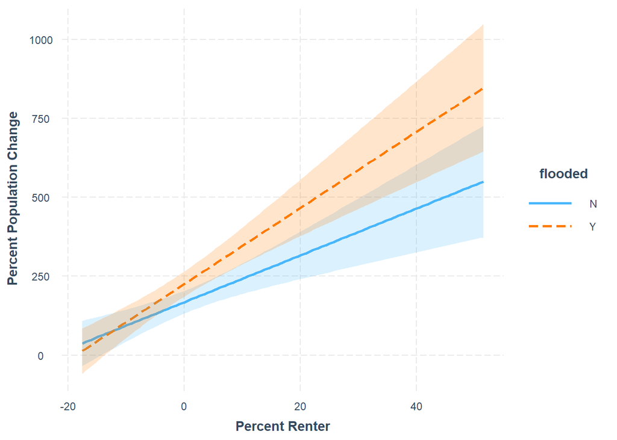

```r
interact_plot(interaction_model, pred = pct_renter_2011E, modx = flooded,
              interval = TRUE) +
  scale_x_continuous(name = "Percent Renter") +
  scale_y_continuous(name = "Percent Population Change")
```

Interpretation

Based on what we have seen in the multivariate models, we know that whether a tract was flooded (flooded = y) and percent renter both have significant, positive impacts on change in population. But does the relationship between percent renter and population change differ depending on whether a tract was flooded or not?

By interacting whether a tract was flooded (flooded = y) with percent renter, we can see in our interaction plot that the relationship between percent renter and population change is stronger for tracts that were flooded vs those that were not. The R2 of the model did not change, so the model fit did not get any stronger, but the positive relationship between percent renter and population change in tracts that were flooded may be useful to know.

**One note about our interaction plot - we are unsure why neither fit line estimated for population change values <0, which we know exist in our dataset. We feel confident about change in relationship demonstrated by the fit lines, and would be interested to know what, if any, error there is with our plot for future work.

### References

Faber, Jacob William. “Superstorm Sandy and the Demographics of Flood Risk in New York City.” *Human Ecology* 43, no. 3 (2015): 363–78. http://www.jstor.org/stable/24762762.

FEMA National Flood Insurance Program, https://www.fema.gov/bn/flood-maps.

Fussell, Elizabeth, and Elizabeth Harris. “Homeownership and Housing Displacement after Hurricane Katrina among Low-Income African-American Mothers in New Orleans.” *Social Science Quarterly* 95, no. 4 (2014): 1086-1100. doi:10.1111/ssqu.12114.

MIT Election Lab, https://electionlab.mit.edu/.

United States Census Bureau. American Community Survey, 5-year estimates. 2011, 2013.